# **SI 618 - Homework #1: Dive into Data Manipulation**

*Version 2024.09.05.2.CT*

Welcome to your first homework assignment for **SI 618**! In this task, you'll explore the fundamentals of data manipulation, using real-world datasets to practice essential skills. Get ready to dive deep, solve some fun challenges, and level up your data wrangling game!

## **Background**

In this assignment, we’ll dive into some exciting **biometric data** and explore how exercise performance relates to key health metrics. 🚶‍♂️💪

### Your Task:

- You'll apply **data manipulation techniques** we've learned in class and from the readings.
- Feel free to consult resources like:
  - [**pandas documentation**](https://pandas.pydata.org/pandas-docs/stable/) 📘
  - [**Stack Overflow**](https://stackoverflow.com/) 🌐
  - [**Copilot**](https://github.com/features/copilot) (for code suggestions)

Remember, the goal is to practice **real-world problem-solving** using data manipulation skills, so explore, test, and have fun with the data!

### Scoring and Guidelines

This assignment is worth a **total of 100 points**, with the breakdown of points shown beside each question. Please refer to the accompanying rubric on Canvas for more details.

To earn **full points**, ensure the following:

- Your code should conform to the [**PEP 8**](https://www.python.org/dev/peps/pep-0008/) style guidelines for Python. 🐍
- Written responses should be:
  - **Grammatically correct** and free of spelling errors.
  - Following the [**Strunk & White**](https://drive.google.com/file/d/1L0P7xJwjUGBvyb49mL3dw1Bt7hzRTiTl/view) guidelines for clear and effective writing.

### Code Structure

- **Wrap your code in functions** wherever possible! This will make your code reusable for future assignments. 🔁
- Don't forget to include:
  - **Comments** (explain your thought process),
  - **Docstrings** (describe your functions), and
  - **Type hints** (specify the data types).

💡 **Reminder**: Undocumented code **will not** receive full credit.

### Important Notes for Submission

- **Add as many cells as you need** to complete your work.
- Use:
  - **"Code" cells** for writing your Python code, and
  - **"Markdown" cells** for explanations, interpretations, and write-ups.

📝 **Pro tip**: After each question, insert new cells for your solutions and explanations!

⚠️ **Note**: Please **do not remove** any of the existing cells in the notebook.

## 📝 Answer the Following Questions

Each question is worth a certain number of points, indicated beside the question.

🔢 **Tip**: Make sure to provide detailed answers, and don't hesitate to use extra cells for your code and explanations!

### 🟢 Q1: Data Exploration with pandas (10 pts)

This question focuses on writing code and exploring a pandas DataFrame. Note: **Biometric data is not required for this question.**

#### 🔹 Q1a (2pt):

List **5 methods or attributes** that can be used to explore a pandas DataFrame or Series. For each method/attribute, explain:

- What it does, and
- How it can help explore the data.

Make sure to write **complete sentences** for your explanations.

1. `describe()`: we can use `describe()` to get the basic descriptive statistics for a DataFrame, including $n$,. mean and standard deviation.
2. `info()`: `info()` provides basic information including non-null values, data types and memory usage of a DataFrame. We can use `info()` to check the non-null values in each column and the data types of each column.
3. `shape`: `shape` returns a tuple representing the dimensions of the DataFrame. We can use `shape` to check the number of rows and columns of a DataFrame.
4. `head()`: `head()` returns the first $n$ rows of a DataFrame. We can use `head()` to check the first few rows of a DataFrame to get a basic sense of the data.
5. `value_counts()`: `value_counts()` returns the frequencies of unique values in a column. We can use `value_counts()` to check the unique values of a column and the distribution.

#### 🔹 Q1b (4pt):

Write a function to generate a **pandas DataFrame** with the following parameters:

1. **Number of rows**: The number of rows for the DataFrame.
2. **Number of columns**: The number of columns for the DataFrame
3. **Optional column names**: A list of column names (if not provided, default to integers starting from 0 up to number_of_columns - 1).
4. **Optional row index values**: A list of row index values (if not provided, default to integers starting from 0 up to number_of_rows - 1).
5. **Optional random seed**: default = 12345

#### Example - DataFrame

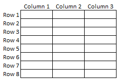

The DataFrame should be filled with **random values** between -1 and 1.

#### 🔹 Q1c (4pt):

Use the function you created to make a DataFrame with:

- Columns: `['a', 'b', 'c']`
- Index: `['x', 'y', 'z']`

Apply the **5 methods/attributes** you listed in Q1a to explore this DataFrame. For each method, write a short explanation of what you learned from it.

```python
# Prerequisites packages
import pandas as pd
import matplotlib.pyplot as plt
```

```python
# Q1b
def create_data_frame(nrows:int, ncols:int, col_names:list = None, row_index:list = None, random_seed:int = 12345) -> pd.DataFrame:
    '''
    Create a DataFrame containing random numbers range from [-1,1) with the specified number of rows and columns, column names, row index, and random seed.

    Parameters:
    -----------
    nrows: int - number of rows in the DataFrame
    ncols: int - number of columns in the DataFrame
    col_names: list - list of column names (if not provided, default to integers starting from 0 up to number_of_columns - 1)
    row_index: list - list of row index (if not provided, default to integers starting from 0 up to number_of_rows - 1)
    random_seed: int - random seed to set for generating random numbers. random_seed is set to 12345 by default

    Returns:
    --------
    pandas.DataFrame - DataFrame with the specified number of rows and columns, column names, row index, and random seed
    '''
    import numpy as np
    np.random.seed(random_seed)

    if col_names is None:
        col_names = list(range(ncols)) # generate the default column names

    if row_index is None:
        row_index = list(range(nrows)) # generate the default row index

    df = pd.DataFrame(np.random.uniform(-1, 1, (nrows, ncols)), columns=col_names, index=row_index)

    return df
```

```python
# Q1c
data = create_data_frame(3,3, col_names=['a', 'b', 'c'], row_index=['x', 'y', 'z']) # create the dataframe
data.describe() # display the summary statistics of the dataframe
```

|  | a | b | c |
| --- | --- | --- | --- |
| count | 3.000000 | 3.000000 | 3.000000 |
| mean | 0.399127 | 0.024852 | 0.018913 |
| std | 0.858081 | 0.350156 | 0.584333 |
| min | -0.590879 | -0.367249 | -0.632162 |
| 25% | 0.134176 | -0.115899 | -0.220536 |
| 50% | 0.859232 | 0.135450 | 0.191089 |
| 75% | 0.894131 | 0.220902 | 0.344451 |
| max | 0.929029 | 0.306354 | 0.497813 |

## 📥 Download the Data

Please download the dataset from the following link:  
[**Kaggle: Body Performance Data**](https://www.kaggle.com/kukuroo3/body-performance-data)

💡 **Tip**: Make sure you're logged into your Kaggle account before downloading.

### 🟢 Q2: Median Statistics (5 pt)

Implement a function to calculate the **median age, height, and weight** of individuals in the dataset, **without** using `pd.DataFrame.describe()`.

- **Rounding**: Round the results to the nearest whole number.
- **Units**: Be sure to indicate the units for each variable in your write-up.

#### 🔹 Summary:

Write 1-2 sentences summarizing the output of your function, clearly stating the median values for age, height, and weight, and mentioning the units.

```python
df_body = pd.read_csv("../data/bodyPerformance.csv", header=0) # read in the body performance dataset
median_age = round(df_body['age'].median()) # calculate the median age
median_height = round(df_body['height_cm'].median()) # calculate the median height (cm)
median_weight = round(df_body['weight_kg'].median()) # calculate the median weight (kg)
print(f"The median age is {median_age} years, the median height is {median_height} cm, and the median weight is {median_weight} kg.") # display the results
print("All the results are rounded to the nearest whole number.")
```

```
The median age is 32 years, the median height is 169 cm, and the median weight is 67 kg.
All the results are rounded to the nearest whole number.
```

The median age is 32 years, the median height is 169 cm, and the median weight is 67 kg. (All the results are rounded to the nearest whole number.)

### 🟢 Q3: Detecting Anomalies (5 pt)

Investigate the dataset for **anomalous data points**. Consider the following example:

- **Diastolic blood pressure** being higher than **systolic blood pressure** is physiologically impossible.

But don’t stop there! 🚩 Explore the data for other potential anomalies as well.

Think about the following as you attempt the next task

- Logical Indexing / Boolean Indexing
- Filter using quantile values

#### 🔹 Task:

- Identify any other types of anomalies that might exist.
- Write 1-2 sentences summarizing your findings and insights from the data.

💡 **Hint**: Think about physiologically or statistically unusual values in the dataset.

```python
df_body.describe()
```

|  | age | height_cm | weight_kg | body fat_% | diastolic | systolic | gripForce | sit and bend forward_cm | sit-ups counts | broad jump_cm |
| --- | --- | --- | --- | --- | --- | --- | --- | --- | --- | --- |
| count | 13393.000000 | 13393.000000 | 13393.000000 | 13393.000000 | 13393.000000 | 13393.000000 | 13393.000000 | 13393.000000 | 13393.000000 | 13393.000000 |
| mean | 36.775106 | 168.559807 | 67.447316 | 23.240165 | 78.796842 | 130.234817 | 36.963877 | 15.209268 | 39.771224 | 190.129627 |
| std | 13.625639 | 8.426583 | 11.949666 | 7.256844 | 10.742033 | 14.713954 | 10.624864 | 8.456677 | 14.276698 | 39.868000 |
| min | 21.000000 | 125.000000 | 26.300000 | 3.000000 | 0.000000 | 0.000000 | 0.000000 | -25.000000 | 0.000000 | 0.000000 |
| 25% | 25.000000 | 162.400000 | 58.200000 | 18.000000 | 71.000000 | 120.000000 | 27.500000 | 10.900000 | 30.000000 | 162.000000 |
| 50% | 32.000000 | 169.200000 | 67.400000 | 22.800000 | 79.000000 | 130.000000 | 37.900000 | 16.200000 | 41.000000 | 193.000000 |
| 75% | 48.000000 | 174.800000 | 75.300000 | 28.000000 | 86.000000 | 141.000000 | 45.200000 | 20.700000 | 50.000000 | 221.000000 |
| max | 64.000000 | 193.800000 | 138.100000 | 78.400000 | 156.200000 | 201.000000 | 70.500000 | 213.000000 | 80.000000 | 303.000000 |

```python
df_body[(df_body.diastolic <= df_body.systolic) &
        (df_body['broad jump_cm'] >0) &
        (df_body.diastolic > 0) &
        (df_body.systolic > 0) ].describe()
```

|  | age | height_cm | weight_kg | body fat_% | diastolic | systolic | gripForce | sit and bend forward_cm | sit-ups counts | broad jump_cm |
| --- | --- | --- | --- | --- | --- | --- | --- | --- | --- | --- |
| count | 13378.000000 | 13378.000000 | 13378.000000 | 13378.000000 | 13378.000000 | 13378.000000 | 13378.000000 | 13378.000000 | 13378.000000 | 13378.000000 |
| mean | 36.768501 | 168.564255 | 67.447521 | 23.234708 | 78.801144 | 130.264090 | 36.970811 | 15.209309 | 39.786216 | 190.273367 |
| std | 13.622518 | 8.425821 | 11.947601 | 7.252437 | 10.694893 | 14.616208 | 10.618461 | 8.456743 | 14.257565 | 39.543671 |
| min | 21.000000 | 125.000000 | 26.300000 | 3.000000 | 6.000000 | 77.000000 | 0.000000 | -25.000000 | 0.000000 | 20.000000 |
| 25% | 25.000000 | 162.400000 | 58.200000 | 18.000000 | 71.000000 | 120.000000 | 27.500000 | 10.900000 | 30.000000 | 162.000000 |
| 50% | 32.000000 | 169.200000 | 67.420000 | 22.800000 | 79.000000 | 130.000000 | 37.900000 | 16.200000 | 41.000000 | 193.000000 |
| 75% | 48.000000 | 174.800000 | 75.300000 | 28.000000 | 86.000000 | 141.000000 | 45.200000 | 20.700000 | 50.000000 | 221.000000 |
| max | 64.000000 | 193.800000 | 138.100000 | 78.400000 | 126.000000 | 201.000000 | 70.500000 | 213.000000 | 80.000000 | 303.000000 |

Some anomalies data points:

1. Some data points with diastolic blood pressure higher than systolic blood pressure.
2. Some data points with 0 mmHg diastolic blood pressure or 0 mmHg systolic blood pressure.
3. Filtering out these data points, some data points with too low diastolic blood pressure (lowest 6 mmHg)
4. Some data points with 0 cm broad jump distance, which is quite not possible.

### 🟢 Q4: Visualizing Age, Weight, and Height (10 pt)

Your task is to generate **histogram plots** to visualize the differences in **age, weight, and height** between gender M and gender F participants.

#### 🔹 Instructions:

- Create the histograms using **only** the **matplotlib-pandas** integration (you cannot use Seaborn, Bokeh, or Plotly).
- After generating the plots, write a brief description of each, pointing out any interesting observations or patterns you notice.

💡 **Hint**: Look for differences in distribution, outliers, or trends between the genders.

```
gender
F    Axes(0.125,0.11;0.775x0.77)
M    Axes(0.125,0.11;0.775x0.77)
Name: age, dtype: object
```

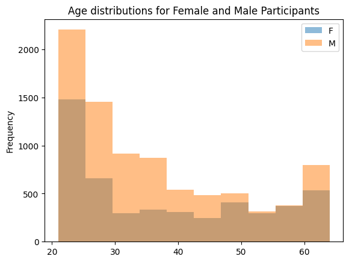

```python
df_body.groupby('gender')['age'].plot(kind='hist', alpha=0.5, legend=True, title='Age distributions for Female and Male Participants')
```

For both genders, we have most respondents aged between 20 and 30 years. Generally we have more male participants than female participants, especially in the age group of 20-40 years old.

### 🟢 Q5: Understanding Blood Pressure Categories (15 pt)

#### Background:

Blood pressure is measured using two numbers:

- **Systolic** (the upper number)
- **Diastolic** (the lower number)

For example, a blood pressure of **120/80** means the systolic pressure is **120 mm Hg** and the diastolic pressure is **80 mm Hg**. Blood pressure readings are important for identifying heart health and are classified into several categories. Here’s a quick summary of the categories:

| Category | Systolic (mm Hg) | Diastolic (mm Hg) |
| --- | --- | --- |
| **Normal** | Below 120 | Below 80 |
| **Elevated** | 120-129 | Below 80 |
| **Stage 1 Hypertension** | 130-139 | 80-89 |
| **Stage 2 Hypertension** | 140 or higher | 90 or higher |
| **Hypertensive Crisis** | Higher than 180 | Higher than 120 |

#### 🔹 Task:

**Part A (8 pt):**  
Using the categories above, report the **number of people** who fall into each blood pressure category in the dataset.

**Part B (7 pt):**  
In 2017, the blood pressure guidelines changed:

- **Before 2017**, hypertension was defined as a systolic pressure of **140 mm Hg** or more for people younger than 65, and **150 mm Hg** or more for those aged 65 and older.
- **After 2017**, hypertension is defined at a lower level (starting at 130/80 mm Hg).

#### Your Job:

1. Analyze how the **change in guidelines** affects the classification of individuals.
   - For example: how many people were considered hypertensive before 2017, and how many are classified as hypertensive after the change?
2. Make reasonable assumptions about how to use systolic and diastolic pressures for your analysis. Clearly state these assumptions in your write-up.

💡 **Hint**: Consider analyzing the data for different age groups (<65 and 65+), and decide whether to base your categorization on systolic, diastolic, or both measures.

#### 🔹 Summary:

- Clearly report the number of people in each category.
- Discuss how the new guidelines (post-2017) affect the classification compared to the old guidelines. Blood pressure measurements fall into several categories:

**Normal Blood Pressure** - Your blood pressure is normal if it's below 120/80 mm Hg.

**Elevated Blood Pressure** - Elevated blood pressure is a systolic pressure ranging from 120 to 129 mm Hg and a diastolic pressure below (not above) 80 mm Hg. Elevated blood pressure may also be called prehypertension.

**Stage 1 Hypertension** - Stage 1 hypertension is a systolic pressure ranging from 130 to 139 mm Hg or a diastolic pressure ranging from 80 to 89 mm Hg.

**Stage 2 Hypertension** - More-severe hypertension, stage 2 hypertension is a systolic pressure of 140 mm Hg or higher or a diastolic pressure of 90 mm Hg or higher.

**Hypertensive Crisis** - A blood pressure measurement higher than 180/120 mm Hg is an emergency situation that requires urgent medical care.

a) Report the number of people in each of those categories.

b) The guidelines were recently changed: prior to 2017, the guidelines set the threshold at 140/90 mm Hg for people younger than age 65 and 150/80 mm Hg for those ages 65 and older to be diagnosed with hypertension. Create and implement analyses that allow you to demonstrate how the change in guidelines affects the categorization of people into the different categories. Make reasonable assumptions (and state them) about whether to use diastolic, systolic, both, or either of those measures when implementing your analysis. Note that the new guidelines offer more categories than the older guidelines.

```python
def categorize_blood_pressure(systolic, diastolic, age, new_rule = True):
    '''
        This function categorizes blood pressure based on the systolic and diastolic blood pressure data.
        The function presumes using the new rule by default.
    '''
    if systolic < 120 and diastolic < 80:
        return 'Normal'
    elif 120 <= systolic <= 129 and diastolic < 80:
        return 'Elevated'
    elif 130 <= systolic <= 139 or 80 <= diastolic <= 89:
        return 'Stage 1 Hypertension'
    elif systolic >= 140 or diastolic >= 90:
        return 'Stage 2 Hypertension'
    elif systolic > 180 or diastolic > 120:
        return 'Hypertensive Crisis'
    else:
        return 'Undefined'

def categorize_hypertension(systolic, diastolic, age, new_rule = True):
    '''
        This function categorizes hypertension based on the systolic and diastolic blood pressure data.
        The function presumes using the new rule by default.
    '''
    if new_rule:
        if systolic >= 130 or diastolic >= 80:
            return 'Hypertensive'
        else:
            return 'Non-Hypertensive'
    else:
        if (systolic >= 140 or diastolic >=90) and age<65:
            return 'Hypertensive'
        elif (systolic >= 150 or diastolic >= 80) and age>=65:
            return 'Hypertensive'
        else:
            return 'Non-Hypertensive'

def categorize_age(age, threshold = 55):
    if age < threshold:
        return 'Under 55'
    else:
        return '55+'
```

```python
# Output the frequencies of each blood pressure category under the post-2017 rule
categories_order = ['Normal', 'Elevated', 'Stage 1 Hypertension', 'Stage 2 Hypertension', 'Hypertensive Crisis', 'Undefined'] # ensure the order of the categories
df_body['BP_Category'] = df_body.apply(lambda row: categorize_blood_pressure(row['systolic'], row['diastolic'], row['age']), axis=1)
df_body['BP_Category'] = pd.Categorical(df_body['BP_Category'], categories=categories_order, ordered=True)
category_counts = df_body['BP_Category'].value_counts().sort_index()

print(category_counts)
```

```
BP_Category
Normal                  2898
Elevated                2090
Stage 1 Hypertension    5936
Stage 2 Hypertension    2469
Hypertensive Crisis        0
Undefined                  0
Name: count, dtype: int64
```

```python
# Calculate the frequencies of hypertension under the pre-2017 rule and post-2017 rule
df_body['Hypertension_pre'] = df_body.apply(lambda row: categorize_hypertension(row['systolic'], row['diastolic'], row['age'], new_rule=False), axis=1)
df_body['Hypertension_post'] = df_body.apply(lambda row: categorize_hypertension(row['systolic'], row['diastolic'], row['age'], new_rule=True), axis=1)

hypertension_pre_counts = df_body['Hypertension_pre'].value_counts()
hypertension_post_counts = df_body['Hypertension_post'].value_counts()

print(hypertension_pre_counts)
print(hypertension_post_counts)
```

```
Hypertension_pre
Non-Hypertensive    8975
Hypertensive        4418
Name: count, dtype: int64
Hypertension_post
Hypertensive        8405
Non-Hypertensive    4988
Name: count, dtype: int64
```

```python
df_body['age_category'] = df_body['age'].apply(categorize_age)
print(df_body['age_category'].value_counts())
```

```
age_category
Under 55    11126
55+          2267
Name: count, dtype: int64
```

```python
hypertension_age = df_body.groupby('age_category')[['Hypertension_pre', 'Hypertension_post']].value_counts()
print(hypertension_age)
```

```
age_category  Hypertension_pre  Hypertension_post
55+           Hypertensive      Hypertensive         1077
              Non-Hypertensive  Non-Hypertensive      636
                                Hypertensive          554
Under 55      Non-Hypertensive  Non-Hypertensive     4352
                                Hypertensive         3433
              Hypertensive      Hypertensive         3341
Name: count, dtype: int64
```

I use both systolic and diastolic blood pressure as the criteria for categorizing blood pressure since both pre-2017 and post-2017 guidelines include both blood pressure measures. The post-2017 guidelines classify more people with hypertension than the pre-2017 guidelines. To illustrate how the change in guidelines affects the analysis of elder age group people, since the dataset does not include age 65+ people, I compare the number of below 55 and 55+ people who are classified as hypertensive under the two guidelines. I expected that the post-2017 guidelines will classify more age 55+ people into hypertensive because of lower thresholds. I found that the post-2017 guidelines classify more people as hypertensive in both age groups.

### 🟢 Q6: Creating Age Categories and Analyzing Sit-Ups (10 pt)

Your task is to create a new variable called **"age_class"** that groups people into the following categories:

- **"early"**: Age < 40
- **"middle"**: Age between 40 and 60 (inclusive)
- **"late"**: Age > 60

#### 🔹 Steps:

1. Create the **"age_class"** variable based on the conditions above.
2. For each age group ("early", "middle", "late"):
   - Report the **mean** number of sit-ups performed.
   - Report the **median** number of sit-ups performed.

💡 **Hint**: Make sure to check your code for correctness by verifying the results for a few random individuals in the dataset.

```python
def categorize_age_three(age):
    if age < 40:
        return 'early'
    elif 40 <= age <= 60:
        return 'middle'
    else:
        return 'late'

df_body['age_category'] = df_body['age'].apply(categorize_age_three)
print(df_body['age_category'].value_counts()) # checking the distribution of the age categories
```

```
age_category
early     8453
middle    3976
late       964
Name: count, dtype: int64
```

```python
df_body[df_body['age_category'] == 'middle'].sample(5) # verifying the correctness of the age categories
```

|  | age | gender | height_cm | weight_kg | body fat_% | diastolic | systolic | gripForce | sit and bend forward_cm | sit-ups counts | broad jump_cm | class | BP_Category | Hypertension_pre | Hypertension_post | age_category |
| --- | --- | --- | --- | --- | --- | --- | --- | --- | --- | --- | --- | --- | --- | --- | --- | --- |
| 12153 | 50.0 | M | 163.0 | 58.3 | 18.9 | 93.0 | 149.0 | 38.0 | 15.4 | 38.0 | 203.0 | A | Stage 2 Hypertension | Hypertensive | Hypertensive | middle |
| 2014 | 52.0 | F | 153.8 | 61.7 | 30.1 | 96.0 | 154.0 | 23.6 | 19.4 | 24.0 | 143.0 | C | Stage 2 Hypertension | Hypertensive | Hypertensive | middle |
| 3312 | 51.0 | F | 156.8 | 57.0 | 34.1 | 53.0 | 123.0 | 27.9 | 14.9 | 14.0 | 110.0 | C | Elevated | Non-Hypertensive | Non-Hypertensive | middle |
| 2492 | 41.0 | F | 165.1 | 57.2 | 30.1 | 92.0 | 143.0 | 19.7 | 9.4 | 21.0 | 159.0 | D | Stage 2 Hypertension | Hypertensive | Hypertensive | middle |
| 1183 | 60.0 | F | 165.3 | 68.6 | 32.1 | 75.0 | 104.0 | 24.6 | 22.6 | 17.0 | 110.0 | A | Normal | Non-Hypertensive | Non-Hypertensive | middle |

```python
mean_sit_ups = df_body.groupby('age_category')['sit-ups counts'].mean()
print('Mean number of sit-ups for each age group:\n', mean_sit_ups)
```

```
Mean number of sit-ups for each age group:
 age_category
early     45.305217
late      24.060166
middle    31.815141
Name: sit-ups counts, dtype: float64
```

```python
median_sit_ups = df_body.groupby('age_category')['sit-ups counts'].median()
print('Median number of sit-ups for each age group:\n', median_sit_ups)
```

```
Median number of sit-ups for each age group:
 age_category
early     47.0
late      25.0
middle    32.0
Name: sit-ups counts, dtype: float64
```

### 🟢 Q7: Calculating and Visualizing BMI (15 pt)

#### 🔹 Part A: Calculating BMI

You’ll need to implement a function to calculate each person's **Body Mass Index (BMI)** using the following formula:

- **BMI formula (metric system)**:

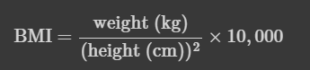

1. Write a function that accepts **weight (kg)** and **height (cm)** as parameters and returns the **BMI**.
2. Use this function to create a new column in your DataFrame called **'BMI'**.

💡 **Note**: The CDC provides a detailed explanation of BMI calculation, which you can refer to [here](https://www.cdc.gov/nccdphp/dnpao/growthcharts/training/bmiage/page5_1.html).

#### 🔹 Part B: Visualizing BMI

Once you’ve added the BMI values to your DataFrame, create two histograms of the BMI using the **pandas-matplotlib integration**:

- One histogram for **gender F**.
- One histogram for **gender M**.

#### 🔹 Part C: Analysis

Compare the two histograms and describe:

- Any **similarities** in the distributions.
- Any **differences** between gender F and gender M.

💡 **Hint**: Think about aspects like the **shape of the distribution**, the **spread of BMI values**, and any **outliers** in the data.

```python
def calculate_bmi(weight, height):
    '''
    Calculate the Body Mass Index (BMI) using the formula: weight / height(cm)^2 * 10000
    '''
    return (weight / height**2)*10000
```

```python
# Q7a
df_body['BMI'] = df_body.apply(lambda row: calculate_bmi(row['weight_kg'], row['height_cm']), axis=1)
print(df_body.groupby('gender')['BMI'].describe())
```

```
         count       mean       std        min        25%        50%  \
gender
F       4926.0  22.104225  2.835768  11.103976  20.185997  21.740786
M       8467.0  24.479737  2.632064  11.314973  22.784071  24.286919

              75%        max
gender
F       23.600966  42.906509
M       25.937514  39.949756
```

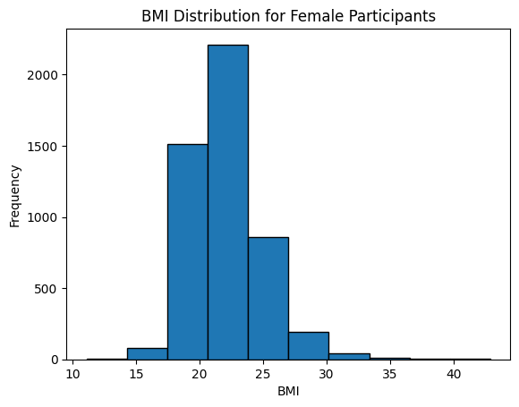

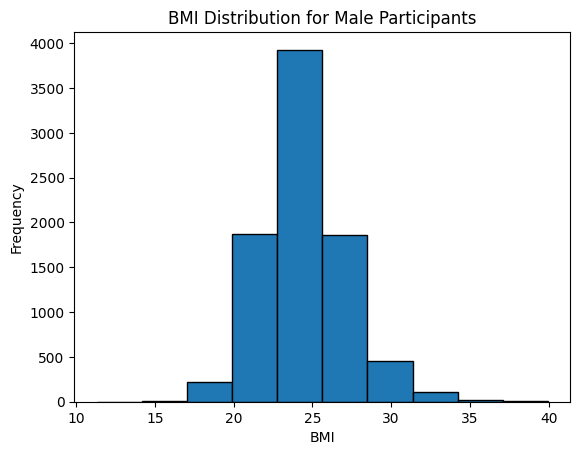

```python
#Q7b

# Create a histogram for gender M
df_body[df_body['gender'] == 'F']['BMI'].plot(kind='hist', edgecolor='black')
plt.title('BMI Distribution for Female Participants')
plt.xlabel('BMI')
plt.show()

# Create a histogram for gender M
df_body[df_body['gender'] == 'M']['BMI'].plot(kind='hist', edgecolor='black')
plt.title('BMI Distribution for Male Participants')
plt.xlabel('BMI')
plt.show()
```

Q7c: Both BMI distributions for male and female participants center around 20-25. The mean BMI score for male participants is higher than female participants. The BMI distribution for female participants is more spread and a bit right-skewed, while the BMI distribution for male distribution is similar to normal distribution. BMI distribution for female participants has higher outliers than that for male.

### 🟢 Q8: Comparing Health Metrics by Gender (12 pt)

Your task is to compare the **mean values** of the following health metrics between **gender F** and **gender M**:

- **Height** (cm)
- **Weight** (kg)
- **Body fat %**
- **Grip force** (kg)
- **Sit and bend forward** (cm)
- **Sit-ups count** (reps)

#### 🔹 Steps:

1. **Quantitative Analysis**:
   - Use pandas to calculate the **mean values** for each metric for both gender F and gender M.
   - Make sure to include the **units** for each metric in your summary.
2. **Visual Analysis**:
   - Create visualizations (e.g., bar plots, histograms) to compare the distribution of these metrics between the two genders. Use **matplotlib** to generate these plots.
3. **Functionality**:
   - Where possible, implement **functions** to perform these comparisons (e.g., a function that calculates mean values for each gender).

#### 🔹 Summary:

Write a brief summary of your findings, discussing:

- The differences in the mean values between gender F and gender M.
- Any interesting observations or patterns you notice in the visualizations.
- Ensure you mention the **units** for each metric in your write-up.

```python
# Q8a
metrics = ['height_cm', 'weight_kg', 'body fat_%', 'gripForce', 'sit and bend forward_cm', 'sit-ups counts']

# Calculate the mean values for each metric for both genders
mean_values = df_body.groupby('gender')[metrics].mean()

print(mean_values)
```

```
         height_cm  weight_kg  body fat_%  gripForce  sit and bend forward_cm  \
gender
F       160.485404  56.905899   28.486085  25.817994                18.839791
M       173.257399  73.580187   20.188151  43.448420                13.097073

        sit-ups counts
gender
F            30.888348
M            44.939176
```

Based on the mean values, male have higher height (173cm vs. 160cm), weight (73.6kg vs 56.9 kg) but lower body fat percentage (20.2% vs. 28.5%) on average compared to female participants. Male participants have higher grip force (43.4kg vs. 25.8kg) and sit-ups count (45 vs. 31) on average but lower sit and bend forward distance (13.1cm vs. 18.8cm) compared to female participants.

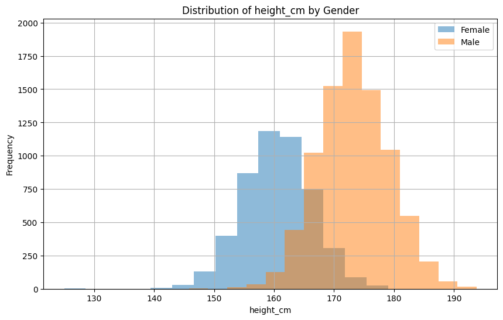

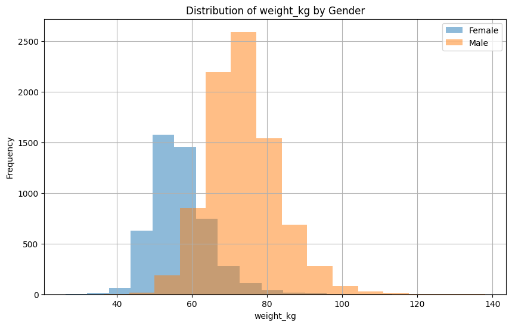

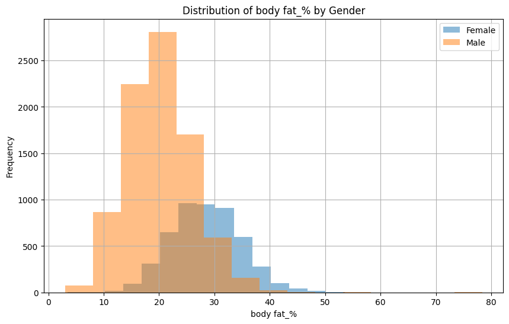

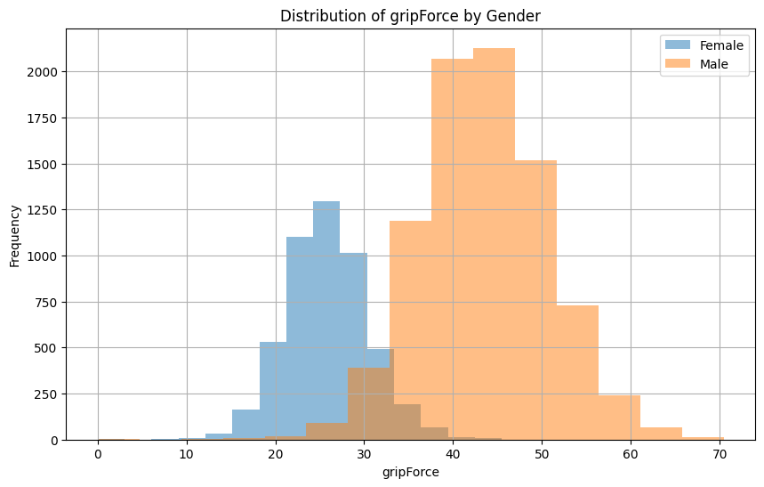

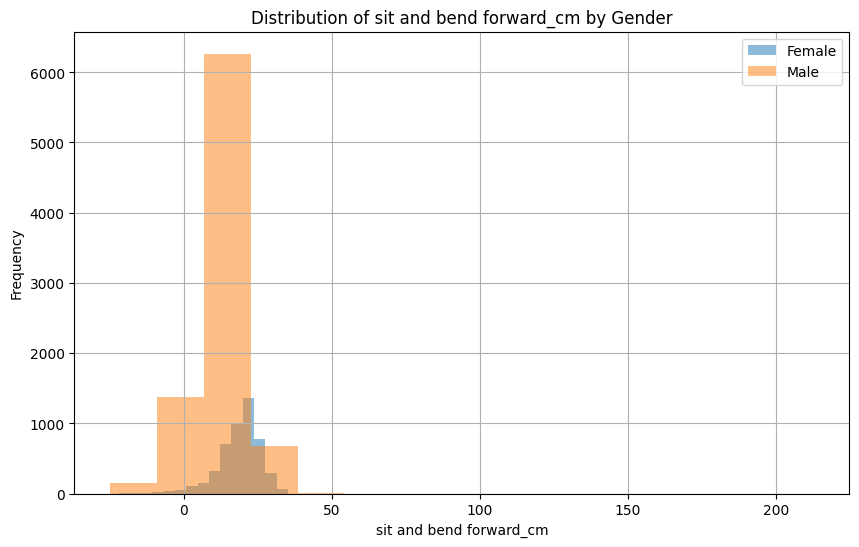

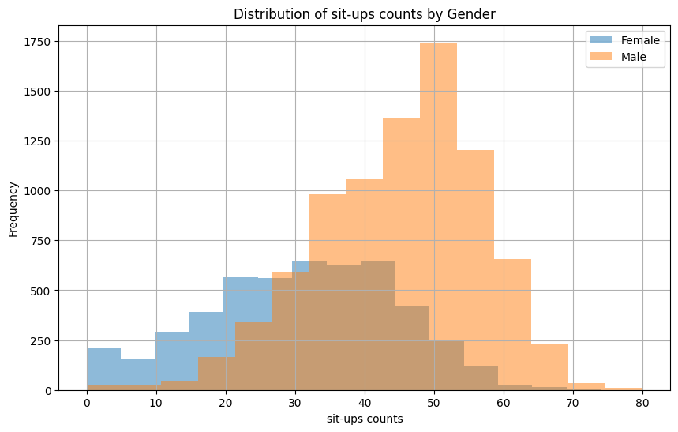

```python
# Q8b

for metric in metrics:
    plt.figure(figsize=(10, 6))
    df_body[df_body['gender'] == 'F'][metric].hist(alpha=0.5, label='Female', bins=15) # create the histogram for female
    df_body[df_body['gender'] == 'M'][metric].hist(alpha=0.5, label='Male',  bins=15) # create the histogram for female
    plt.title(f'Distribution of {metric} by Gender')
    plt.xlabel(metric)
    plt.ylabel('Frequency')
    plt.legend()
    plt.show()
```

The histogram of weight shows that the distribution of weight for male participants is more spread out than that of female participants. There are also outliers in the distribution of sit and bend forward counts for male. The maximum value for male is 213 cm, which is nearly impossible for human. If the outliers are left out, the mean sit and bend forward values for male will be lower. There are also more outliers in the weight distribution for male participants. The frequencies of these metrics also show that there are much more male participants than female.

### 🟢 Q9: Calculating Fitness Scores (18 pt)

In this task, you will assess the fitness levels of individuals using the following three metrics:

- **Grip Force** (a measure of strength)
- **Sit and Bend Forward** (a measure of flexibility)
- **Sit-ups Count** (a measure of strength and endurance of abdominal and hip-flexor muscles)

#### 🔹 Steps:

1. **Calculate Z-scores**:
   - For each of the three metrics, calculate the z-score using the following formula:

$$ z = \frac{x - \mu}{\sigma} $$

Where:

- $x$ is the individual’s score,
- $\mu$ is the mean of the metric, and
- $\sigma$ is the standard deviation of the metric.
2. **Create a Fitness Score**:
   - Create an **overall fitness score** by adding the z-scores of the three metrics together for each individual.
3. **Categorize Fitness Levels**:
   - Use `pd.qcut()` to assign each individual to one of four categories, from the **lowest fitness score** to the **highest fitness score**.
4. **Function Implementation**:
   - Implement one or more functions to perform these calculations and categorization.

#### 🔹 Part A (10 pt):

- Report the **number of individuals** in each of the four fitness score categories.

#### 🔹 Part B (8 pt):

- Compare your fitness categories to the `class` column in the dataset.
- Write a brief summary commenting on:
  - How closely your fitness categories correspond to the `class` column.
  - Any interesting observations or discrepancies between the two.

💡 **Hint**: Remember to include units in your analysis and write-up.

```python
def calculate_z_score(x, mean, std_dev):
    '''
    This function calculates the z-score of a given value x using the formula: (x - mean) / std_dev
    '''
    return (x - mean) / std_dev
```

```python
# Calculate z-scores for each metric
for metric in ['gripForce', 'sit and bend forward_cm', 'sit-ups counts']:
    mean = df_body[metric].mean()
    std_dev = df_body[metric].std()
    df_body[metric + '_z'] = df_body[metric].apply(lambda x: calculate_z_score(x, mean, std_dev))
```

```python
# Create an overall fitness score
df_body['fitness_score'] = df_body[['gripForce_z', 'sit and bend forward_cm_z', 'sit-ups counts_z']].sum(axis=1)

# Categorize fitness levels
df_body['fitness_level'] = pd.qcut(df_body['fitness_score'], 4, labels=['lowest', 'low', 'high', 'highest'])
```

```python
# report the number of participants in each fitness level
fitness_level_counts = df_body['fitness_level'].value_counts()
print(fitness_level_counts)
```

```
fitness_level
lowest     3349
low        3348
high       3348
highest    3348
Name: count, dtype: int64
```

```python
# Create a cross table
cross_table = pd.crosstab(df_body['fitness_level'], df_body['class'])
print(cross_table)
```

```
class             A     B    C     D
fitness_level
lowest           87   404  887  1971
low             638   937  969   804
high            974   984  981   409
highest        1649  1022  512   165
```

The `fitness level` we created is similar to the `class`. Most of the lowest fitness level participants are classified as 'D' in `class`. And most of the highest fitness level participants are classified as 'A' in `class`. But there are more fuzziness in terms of the low and high fitness level. Also, there are some discrepancies between the two categorizations. For example, some participants classified as 'A' in `class` are classified as low and lowest in `fitness level`. This discrepancy may be due to the fact that the `class` column takes in more factors than the three metrics, e.g. age. We can also do correlation analysis to see how well the three metrics correlate with the `class` column. The correlation shown in the following cell is 0.53, indicating medium correlation between the `fitness level` and `class` column.

```python
# Mapping the class and fitness level to integers for correlation calculation
class_mapping = {'A': 1, 'B': 2, 'C': 3, 'D': 4}
level_mapping = {'highest':1, 'high':2, 'low':3, 'lowest':4}

# Replace the class labels with numbers
df_body['class_code'] = df_body['class'].replace(class_mapping)
df_body['fitness_level_code'] = df_body['fitness_level'].replace(level_mapping)


correlation = df_body['fitness_level_code'].corr(df_body['class_code'])
print(f'The correlation between fitness level and class is: {correlation}')
```

```
The correlation between fitness level and class is: 0.5303797212625757
```

### 🟢 IMPORTANT: Final Checks

Before you submit your notebook, please ensure that:

- Your complete notebook **runs without errors** from top to bottom.  
  💡 **Tip**: Use the "Run All" feature to quickly check this.

## 📤 Submission Instructions

Submit your completed assignment in both of the following formats:

1. **.IPYNB** (Jupyter Notebook format)
2. **.HTML** (Webpage format)

Upload your files to **Canvas** before the deadline. Be sure to check that you have uploaded the correct files (e.g., don't accidentally submit an in-class notebook as your homework assignment).